# FIT5197 2025 S2 Assignment - Covers the lecture and tutorial materials up to, and including, week 8

**SPECIAL NOTE:** Please refer to the assessment page for rules, general guidelines and marking rubrics of the assessment (the marking rubric for the kaggle competition part will be released near the deadline in the same page). Failure to comply with the provided information will result in a deduction of mark (e.g., late penalties) or breach of academic integrity.

**Mandatory Mathematics Interview (20%):**

To receive a grade for this assignment, you must complete a Mathematics Interview worth 20% of the assignment mark. The interview verifies that the work is your own and focuses on concepts used in the assignment. Students who do not attend will receive 0 for the assignment.

# Part 1 Point Estimation (30 marks)

**WARNING:** you should strictly follow the 3-steps strategy as detailed in question 2 of week 5 tutorial (or any answer formats presented in the Week 5 quiz) to answer for the questions that are related to MLE estimators presented in this part. Any deviations from the answer format might result in a loss of marks!

## Question 1 (7.5 marks)

Let $X\,{\sim}\,\mathcal{IG}\left(\theta: \left(\mu, \lambda\right)\right),\;\,\forall\, \mu>0 \text{ and } \lambda>0$. This means the random varible $X$ follows the **inverse Gaussian distribution** with the set $\left(\theta: \left(\mu, \lambda\right)\right)$ acting as the parameters of said distribution. Given that we observe a sample of size $n$ that is independently and identically distributed from this distribution ([i.i.d](https://en.wikipedia.org/wiki/Independent_and_identically_distributed_random_variables)), $\mathbf{x}=$ $\left(x_{1}, \ldots, x_{n}\right)$, please find the [maximum likelihood estimate](https://en.wikipedia.org/wiki/Maximum_likelihood_estimation) for $\mu$ and $\lambda$, that is $\mu_{\text{MLE}}$ and $\lambda_{\text{MLE}}$. The probability density function (**PDF**) is as follows:

$$ f(x \mid \mu, \lambda)=\left\{\begin{array}{cc} \left(\frac{\lambda}{2 \pi x^{3}}\right)^{1 / 2} e^{\frac{-\lambda(x-\mu)^{2}}{2 \mu^{2} x}}, & x>0 \\ 0, & x \leq 0 \end{array}\right. $$

### Answer

We aim to find the maximum likelihood extimators (MLEs) of $\mu$ and $\lambda$ Let $x_1, \ldots, x_n>0$ be i.i.d. $I G(\mu, \lambda)$ with

$$ f(x \mid \mu, \lambda)=\left(\frac{\lambda}{2 \pi x^3}\right)^{1 / 2} \exp \left\{-\frac{\lambda(x-\mu)^2}{2 \mu^2 x}\right\}, \quad \mu>0, \lambda>0 . $$

The likelihood is

$$ L(\mu, \lambda ; \mathbf{x})=\prod_{i=1}^n f\left(x_i \mid \mu, \lambda\right) . $$

Negative log-likelihood

The log-likelihood is

$$ \log\!\left(\frac{\lambda}{2\pi x_i^3}\right)^{1/2}= \tfrac{1}{2}\log\lambda-\tfrac{1}{2}\log(2\pi)-\tfrac{3}{2}\log x_i, $$

and constants in $-\tfrac{1}{2}\log(2\pi)$ are dropped.

$$ \ell(\mu, \lambda)=\sum_{i=1}^n \log f\left(x_i \mid \mu, \lambda\right)=\frac{n}{2} \log \lambda-\frac{3}{2} \sum_{i=1}^n \log x_i-\frac{\lambda}{2} \sum_{i=1}^n \frac{\left(x_i-\mu\right)^2}{\mu^2 x_i} . $$

Define (to simplify notation)

$$ T(\mu)=\sum_{i=1}^n \frac{\left(x_i-\mu\right)^2}{\mu^2 x_i}=\frac{\sum_{i=1}^n x_i}{\mu^2}-\frac{2 n}{\mu}+\sum_{i=1}^n \frac{1}{x_i} . $$

The negative log-likelihood is

$$ \mathcal{L}(\mu, \lambda)=-\ell(\mu, \lambda)=-\frac{n}{2} \log \lambda+\frac{3}{2} \sum_{i=1}^n \log x_i+\frac{\lambda}{2} T(\mu) . $$

Find the MLE (differentiate the negative log-likelihood)

(a) With respect to $\mu$

Only the last term depends on $\mu$ :

$$ \frac{\partial \mathcal{L}}{\partial \mu}=\frac{\lambda}{2} T^{\prime}(\mu) . $$

Differentiate $T(\mu)$ explicitly:

$$ T(\mu)=\left(\sum x_i\right) \mu^{-2}-2 n \mu^{-1}+\sum \frac{1}{x_i} \Rightarrow T^{\prime}(\mu)=-\frac{2 \sum x_i}{\mu^3}+\frac{2 n}{\mu^2} . $$

Set the score to zero:

$$ \frac{\partial \mathcal{L}}{\partial \mu}=0 \Longleftrightarrow-\frac{2 \sum x_i}{\mu^3}+\frac{2 n}{\mu^2}=0 \Longleftrightarrow \sum_{i=1}^n x_i=n \mu \Longrightarrow \hat{\mu}=\bar{x}=\frac{1}{n} \sum_{i=1}^n x_i . $$

(b) With respect to $\lambda$

$$ \frac{\partial \mathcal{L}}{\partial \lambda}=-\frac{n}{2 \lambda}+\frac{1}{2} T(\mu)=0 \Longrightarrow \hat{\lambda}=\frac{n}{T(\hat{\mu})} . $$

Since

$$ T(\mu)=\frac{\sum_{i=1}^n x_i}{\mu^2}-\frac{2 n}{\mu}+\sum_{i=1}^n \frac{1}{x_i} . $$

and $$ \hat{\mu}=\bar{x}=\frac{1}{n} \sum_{i=1}^n x_i $$ so $$ \sum_{i=1}^n x_i={n} \hat{\mu} $$ By implementing this on $T(\mu)$ we get $$ T(\hat{\mu})=\sum_{i=1}^n \frac{1}{x_i}-\frac{n}{\hat{\mu}}=\sum_{i=1}^n \frac{1}{x_i}-\frac{n}{\bar{x}}, $$

with that

$$ \Rightarrow \hat{\lambda}=\frac{n}{\sum_{i=1}^n \frac{1}{x_i}-\frac{n}{\bar{x}}} $$

Final Maximum Likelihood Estimates

$$ \hat{\mu}_{\mathrm{MLE}}=\bar{x}, \quad \hat{\lambda}_{\mathrm{MLE}}=\frac{n}{\sum_{i=1}^n \frac{1}{x_i}-\frac{n}{\bar{x}}} . $$

## Question 2 (7.5 marks)

Suppose that we know that the random variable $X{\,\sim\,}\mathcal{Dist}(\mu=\theta, \sigma^2=\theta^2)$ follows the PDF given below:

$$ \begin{equation} f\left(x|\theta\right)= \begin{cases} \frac{1}{\theta} \exp(-\frac{x}{\theta}) & x > 0 \\ 0 & \text{otherwise.} \end{cases} \end{equation} $$

Given a sample of $n$ [i.i.d](https://en.wikipedia.org/wiki/Independent_and_identically_distributed_random_variables) observations $\mathbf{x}=$ $\left(x_{1}, \ldots, x_{n}\right)$ from this distribution, please answer the following questions:

**(a)** Derive the MLE estimator for $\theta$, i.e., $\hat{\theta}_{\text{MLE}}$, and show that it is unbiased. [2.5 Marks]

**(b)** Find an estimator with better MSE (i.e smaller MSE) compared to the $\hat{\theta}_{\text{MLE}}$ obtained from (a). [5 Marks]

### Answer

Given Let $X_1, \ldots, X_n$ be i.i.d. with

$$ f(x \mid \theta)=\frac{1}{\theta} e^{-x / \theta} $$

we know that

$$ \bar{X}=\frac{1}{n} \sum_{i=1}^n X_i . $$

#### a)

Likelihood

$$ L(\theta ; \mathbf{x})=\prod_{i=1}^n \frac{1}{\theta} e^{-x_i / \theta} $$ $$ =\theta^{-n} \exp \left(-\frac{\sum_{i=1}^n x_i}{\theta}\right) . $$

Log-likelihood

$$ \ell(\theta)=\log L(\theta ; \mathbf{x})=-n \log \theta-\frac{\sum_{i=1}^n x_i}{\theta} . $$

Negative log-likelihood

$$ \mathcal{L}(\theta)=-\ell(\theta)=n \log \theta+\frac{\sum_{i=1}^n x_i}{\theta} . $$

MLE of $\theta$

Differentiate $\mathcal{L}$ and set to zero:

$$ \frac{d \mathcal{L}}{d \theta}=\frac{n}{\theta}-\frac{\sum_{i=1}^n x_i}{\theta^2}=0 $$ $$ \quad \Longrightarrow \quad n \theta=\sum_{i=1}^n x_i . $$

Hence

$$ \hat{\theta}_{\mathrm{MLE}}=\bar{X}=\frac{1}{n} \sum_{i=1}^n x_i $$

For Exp(mean $\theta$ ):

$$ \mathbb{E}\left[X_i\right]=\theta, \quad \operatorname{Var}\left(X_i\right)=\theta^2 . $$

Using linearity of expectation:

$$ \mathbb{E}[\bar{X}]=\mathbb{E}\left[\frac{1}{n} \sum_{i=1}^n X_i\right] $$ $$ =\frac{1}{n} \sum_{i=1}^n \mathbb{E}\left[X_i\right] $$ $$ =\frac{1}{n} \cdot n \theta $$ $$ =\theta . $$

So the bias is

$$ \operatorname{Bias}(\bar{X})=\mathbb{E}[\bar{X}]-\theta=\theta-\theta=0 . $$ So, $\theta$ is unbiased

#### b)

Variance of $\bar{X}$

$$ \operatorname{Var}(\bar{X})=\operatorname{Var}\left(\frac{1}{n} \sum_{i=1}^n X_i\right) $$

When taking constant out of variance. it will get squared

$$ =\frac{1}{n^2} \operatorname{Var}\left(\sum_{i=1}^n X_i\right) $$ $$ =\frac{1}{n^2} \sum_{i=1}^n \operatorname{Var}\left(X_i\right) $$ $$ =\frac{1}{n^2} \cdot n \theta^2 $$ $$ =\frac{\theta^2}{n} . $$

An estimator with smaller MSE than $\bar{X}$

Consider $\bar{\theta}=c \bar{X}$ with a constant $c>0$.

Expectation and bias

$$ \mathbb{E}[\tilde{\theta}]=c \mathbb{E}[\bar{X}]=c .\theta, $$ $$ \operatorname{Bias}(\bar{X})=\mathbb{E}[\bar{X}]-\theta $$ $$ \quad \operatorname{Bias}(\tilde{\theta})=(c-1) \theta $$

Variance

$$ \operatorname{Var}(\bar{\theta})=c^2 \operatorname{Var}(\bar{X})=c^2 \frac{\theta^2}{n} $$

MSE

$$ \operatorname{MSE}(\tilde{\theta})=\operatorname{Var}(\tilde{\theta})+\operatorname{Bias}(\tilde{\theta})^2 $$ $$ =\left[\theta^2(c-1)^2+\theta^2\frac{c^2}{n}\right] $$ $$ =\theta^2\left[(c-1)^2+\frac{c^2}{n}\right] . $$

Diiferentiating with respect to $c$ and equals to 0 :

$$ \frac{d}{d c}\left[(c-1)^2+\frac{c^2}{n}\right]=2(c-1)+\frac{2 c}{n} $$ $$ 2(c-1)+\frac{2 c}{n}=0 $$ $$ \Longrightarrow c=\frac{n}{n+1} . $$

Substitute $c=\frac{n}{n+1}$ in MSE Variance term:

$$ c^2 \frac{\theta^2}{n}=\left(\frac{n}{n+1}\right)^2 \frac{\theta^2}{n}=\frac{n^2}{(n+1)^2} \cdot \frac{\theta^2}{n}=\frac{n}{(n+1)^2} \theta^2 . $$

Bias-squared term:

$$ (c-1)^2 \theta^2=\left(\frac{n}{n+1}-1\right)^2 \theta^2=\left(\frac{n-(n+1)}{n+1}\right)^2 \theta^2=\left(-\frac{1}{n+1}\right)^2 \theta^2=\frac{1}{(n+1)^2} \theta^2 . $$

Adding them to obtain MSE :

$$ \operatorname{MSE}(\tilde{\theta})=\theta^2\left[\frac{n}{(n+1)^2}+\frac{1}{(n+1)^2}\right]=\theta^2\left[\frac{n+1}{(n+1)^2}\right]=\frac{\theta^2}{n+1} $$

## Question 3 (7.5 marks)

Suppose that we know that a random variable $X$ follows the distribution given below:

$$ f\left(x|\theta\right)= \frac{{2 \choose x}\theta^x\left(1-\theta\right)^{2-x}}{1-\left(1-\theta\right)^2}, \; x= \{1,2\} $$

Imagine that we observe a sample of $\textbf{n}$ [i.i.d](https://en.wikipedia.org/wiki/Independent_and_identically_distributed_random_variables) random varaibles $\mathbf{x}=$ $\left(x_{1}, \ldots, x_{n}\right)$ and want to model them using this distribution. Please use the concept of maximum likelihood to estimate for the parameter $\theta$.

### Answer

Likelihood

For i.i.d. $X_1, \ldots, X_n$ with support $\{1,2\}$ and

$$ p(x \mid \theta)=\frac{\binom{2}{x} \theta^x(1-\theta)^{2-x}}{1-(1-\theta)^2}=\frac{\binom{2}{x} \theta^x(1-\theta)^{2-x}}{\theta(2-\theta)}, \quad x \in\{1,2\}, $$

the likelihood is

$$ \begin{aligned} L(\theta ; \mathbf{x}) & =\prod_{i=1}^n \frac{\binom{2}{x_i} \theta^{x_i}(1-\theta)^{2-x_i}}{\theta(2-\theta)} \\ & =\frac{\left(\prod_{i=1}^n\binom{2}{x_i}\right) \theta^{\sum x_i}(1-\theta)^{2 n-\sum x_i}}{[\theta(2-\theta)]^n} \end{aligned} $$

here $n_1$ is the no. of observations representing 1 and $n_2$ is the no. of observations representing 2

Let $n=n_1+n_2$,

and $S=\sum_{i=1}^n X_i=n_1+2 n_2=n+n_2$.

We are considering $n_1+2 n_2$ as S. So that it will be easier to solve $$ L(\theta)=\frac{\theta^{S}(1-\theta)^{2 n-S}}{[\theta(2-\theta)]^n} $$

Implementing Negative log-likelihood

Ignoring additive constants (that don't depend on $\theta$ ),

$$ \ell(\theta)=\log L(\theta)=S \log \theta+(2 n-S) \log (1-\theta)-n \log (\theta(2-\theta)) . $$

Hence the negative log-likelihood is

$$ \mathcal{L}(\theta)=-\ell(\theta)=-S \log \theta-(2 n-S) \log (1-\theta)+n \log (\theta(2-\theta)) . $$

Find the MLE

Differentiate $\mathcal{L}$ and set to zero:

$$ \frac{d \mathcal{L}}{d \theta}=-\frac{S}{\theta}+\frac{2 n-S}{1-\theta}+n\left(\frac{1}{\theta}-\frac{1}{2-\theta}\right)=0 . $$

Multiply both sides by $\theta(1-\theta)(2-\theta)$ :

$$ S(1-\theta)(2-\theta)-(2 n-S) \theta(2-\theta)-2 n(1-\theta)^2=0 . $$

Now substitute $S=n+n_2$ and $2 n-S=2 n -n-n_2= n-n_2$, expand

$$ \begin{aligned} & =S(1-\theta)(2-\theta)-(2 n-S) \theta(2-\theta)-2 n(1-\theta)^2 \\ & =\left(n+n_2\right)\left(2-3 \theta+\theta^2\right)-\left(n-n_2\right)\left(2 \theta-\theta^2\right)-2 n\left(1-2 \theta+\theta^2\right) \\ & =\left[2 n+2 n_2-3 n \theta-3 n_2 \theta+n \theta^2+n_2 \theta^2\right]-\left[2 n \theta-2 n_2 \theta-n \theta^2+n_2 \theta^2\right]-\left[2 n-4 n \theta+2 n \theta^2\right] \\ & =\left(2 n+2 n_2-2 n\right)+\left(-3 n \theta-3 n_2 \theta-2 n \theta+2 n_2 \theta+4 n \theta\right)+\left(n \theta^2+n_2 \theta^2+n \theta^2-n_2 \theta^2-2 n \theta^2\right) \end{aligned} $$

Thus all $\boldsymbol{\theta}^{\mathbf{2}}$ terms cancel, leaving

$$ 2 n_2-\left(n+n_2\right) \theta=0 $$

Therefore

$$ \hat{\theta}_{\mathrm{MLE}}=\frac{2 n_2}{n+n_2} $$

as we know $n=n_1+n_2$. It becomes

$$ \hat{\theta}=\frac{2 n_2}{n_1+2 n_2} $$

## Question 4 (7.5 marks)

Suppose that we know that the random variable $X$ follows the PDF given below:

$$ \begin{equation} f\left(x|\theta\right)= \begin{cases} e^{-(x-\theta)} & x\geq\theta \\ 0 & \text{otherwise.} \end{cases} \end{equation} $$

Given a sample of $n$ [i.i.d](https://en.wikipedia.org/wiki/Independent_and_identically_distributed_random_variables) observations $\mathbf{x}=$ $\left(x_{1}, \ldots, x_{n}\right)$ from this distribution, please answer the following questions:

**(a)** Derive the MLE estimator for $\theta$, i.e., $\hat{\theta}_{\text{MLE}}$. [4.5 Marks]

**(b)** Show that the estimator $\hat{\theta} = \overline{X} - 1$ (where $\overline{X} = \frac{1}{n}\sum_{i=1}^n X_i$) is an unbiased and consistent estimator for the given distribution. [3 Marks]

### a)

$$ f(x \mid \theta)=e^{-(x-\theta)} \quad \{x \geq \theta\}, \quad \theta \in \mathbb{R} $$

Likelihood

For i.i.d. $x_1, \ldots, x_n$,

$$ L(\theta ; \mathbf{x})=\prod_{i=1}^n e^{-\left(x_i-\theta\right)} \quad \left\{x_i \geq \theta\right\}=\exp \left(-\sum_{i=1}^n x_i+n \theta\right) \mathbf{}\left\{\theta \leq x_{(1)}\right\}, $$

where $x_{(1)}=\min \left(x_1, \ldots, x_n\right)$. Negative log-likelihood

Ignoring the indicator (which only restricts the admissible $\theta$ ), the log-likelihood is

$$ \ell(\theta)=-\sum_{i=1}^n x_i+n \theta \quad \text { for } \theta \leq x_{(1)}, \quad \ell(\theta)=-\infty \text { otherwise } $$

Hence the negative log-likelihood is

$$ \mathcal{L}(\theta)=\sum_{i=1}^n x_i-n \theta \quad\left(\theta \leq x_{(1)}\right), \quad \mathcal{L}(\theta)=+\infty \text { if } \theta>x_{(1)} $$

Find the MLE

Ignoring the constant. Therefore the minimum value for n of $\mathcal{L}$ occurs at the largest feasible $\theta$ :

$$ \hat{\theta}_{\mathrm{MLE}}=x_{(1)}=\min \left(x_1, \ldots, x_n\right) $$

# Part 2 Confidence Interval Estimation & Central Limit Theorem (30 marks)

**WARNING:** If it is not explicitly stated, please assume the 95% confidence or 5% significant level.

## Question 1 (5 marks)

The [SETU](https://www.monash.edu/ups/setu) score of FIT units is known to follow a $\mathcal{N}(\mu=4$, $\sigma^2=0.25)$ distribution. You take a sample of the units and check their last semester's SETU. How many units do you have to sample to have a 95% confidence interval for $\mu$ with width 0.1?

### Answer

95% Confidence Interval ; Width $=0.1$ for $\mu, \sigma^2=0.25$ known

For a normal mean with known variance, the confidence interval is

$$ CI=\bar{X} \pm z_{\alpha / 2} \frac{\sigma}{\sqrt{n}} $$

Hence the half-width (margin of error) is

$$ m=z_{\alpha / 2} \frac{\sigma}{\sqrt{n}} $$

Given a total width of 0.1 , we have $m=0.05$. with $\alpha=0.5$ we got $z_{0.025}=1.96$ and $\sigma=\sqrt{0.25}=0.5$ :

$$ 0.05=1.96 \frac{0.5}{\sqrt{n}} \quad \Longrightarrow \quad \sqrt{n}=\frac{1.96 \times 0.5}{0.05}=19.6 \quad \Longrightarrow \quad n=(19.6)^2=384.16 . $$

Since $n$ must be an integer,

$$ n=385 . $$

## Question 2 (5 marks)

You do a poll to see what fraction $p$ of the students participated in the FIT5197 SETU survey. You then take the average frequency of all surveyed people as an estimate $\hat p$ for $p$. Now it is necessary to ensure that there is at least $99\%$ certainty that the difference between the surveyed rate $\hat p$ and the actual rate $p$ is not more than $5\%$. At least how many people should take the survey?

### ANSWER

CI formula for a proportion For a large sample,

$$ \hat{p} \pm z_{\alpha / 2} \sqrt{\frac{\hat{p}(1-\hat{p})}{n}} . $$

The half-width (margin of error) is

$$ m=z_{\alpha / 2} \sqrt{\frac{p(1-p)}{n}} . $$

Rearrange for $n$

$$ n=\frac{z_{\alpha / 2}^2 p(1-p)}{m^2} . $$

using known values Confidence level $=99 \% \rightarrow z_{0.005}=2.576$. Target margin $m=0.05$. When $p$ is unknown, use the worst case $p=0.5$ because it maximizes $p(1-p)$.

$$ n=\frac{(2.576)^2 \times 0.25}{(0.05)^2} . $$

$$ n=\frac{6.635 \times 0.25}{0.0025}=\frac{1.65875}{0.0025}=663.5 . $$

Rounding up Since $n$ must be an integer:

$$ n=664 . $$

## Question 3 (5 marks)

Suppose you repeated the above polling process multiple times and obtained $100$ confidence intervals, each with confidence level of $99\%$. About how many of them would you expect to be "wrong"? That is, how many of them would not actually contain the parameter being estimated? Should you be surprised if $4$ of them are wrong?

### ANSWER

Each $99 \% \mathrm{Cl}$ has coverage 0.99 , so the probability a single interval is wrong is

$$ \alpha=0.01 . $$

With 100 independent intervals, let $W=$ number of "wrong" intervals. Then

$$ W \sim \operatorname{Binomial}(n=100, p=0.01) . $$

Expected number wrong

$$ \mathbb{E}[W]=n p=100 \times 0.01=1 . $$

Is " 4 wrong" surprising?

We want

$$ P(W \geq 4)=1-\sum_{k=0}^3\binom{100}{k}(0.01)^k(0.99)^{100-k} . $$

Exact (numerical) decomposition

$$ \begin{aligned} & P(W=0)=0.99^{100} \approx 0.3660, \\ & P(W=1)=\binom{100}{1} 0.010 .99^{99} \approx 0.3697, \\ & P(W=2)=\binom{100}{2} 0.01^2 0.99^{98} \approx 0.1840, \\ & P(W=3)=\binom{100}{3} 0.01^3 0.99^{97} \approx 0.0610 . \end{aligned} $$

So

$$ P(W \geq 4) \approx 1-(0.3660+0.3697+0.1840+0.0610) \approx 0.0193 . $$

### Interpretation

Getting 4 wrong out of 100 has probability about 2% under correct 99% Confidence Intervals. Which is rare but not impossible.

## Question 4 (5 marks)

Consider the random variable $X$ following the Bernoulli distribution with a parameter $\theta$, i.e., $X\sim \text{Be}(\theta)$, where $\theta=0.9$. Given that you collect $n$ random variable $X_1, X_2,\ldots, X_n$. Calculate the smallest sample size, ${n}$, you have to observe to guarantee that

$$ P\left(\left|\frac{\sum_1^n X_i}{n} - \theta \right| >0.01\right) < 0.1. $$

### ANSWER

$$ \begin{gathered} X_i \sim \operatorname{Bernoulli}(\theta), \quad \theta=0.9, \quad i=1, \ldots, n \\ \bar{X}=\frac{1}{n} \sum_{i=1}^n X_i, \quad \mathbb{E}\left[X_i\right]=\theta=0.9, \quad \operatorname{Var}\left(X_i\right)=\theta(1-\theta)=0.9 \cdot 0.1=0.09 \\ \quad \operatorname{Var}\left(X_n\right)=\frac{\theta(1-\theta)}{n}\\ \operatorname{Var}(\bar{X})=\frac{0.09}{n} \end{gathered} $$

For estimating the smallest 'n'

By CLT,

$$ \bar{X} \approx \mathcal{N}\left(\theta, \frac{\theta(1-\theta)}{n}\right)=\mathcal{N}\left(0.9, \frac{0.09}{n}\right) . $$

To Standardize $\bar{X}_n$ we use Z- Score method

$$ Z=\frac{\bar{X}_n-\mu}{Std(\bar{X}_n)} = \frac{\bar{X}_n-\theta}{\sqrt{Var(\bar{X}_n)}} $$

$$ Z=\frac{\bar{X}-\theta}{\sqrt{\theta(1-\theta) / n}}=\frac{\bar{X}-0.9}{\sqrt{0.09 / n}} $$

Given That

$$ P\left(\left|\frac{\sum_1^n X_i}{n} - \theta \right| >0.01\right) < 0.1. $$ $$ P(|\bar{X}-\theta| > 0.01) < 0.1 $$

Dividing both sides by Standard deviation of $\bar{X}_n$ where

$$ c=\frac{0.01}{\sqrt{0.09 / n}}=\frac{0.01 \sqrt{n}}{0.3} . $$

We need

$$ P(|Z| \leq c) \geq 0.90 \Longleftrightarrow c \geq z_{0.95}=1.645 . $$

Solve for $n$

$$ \begin{aligned} \frac{0.01 \sqrt{n}}{0.3} & \geq 1.645 \quad \Longleftrightarrow \quad \sqrt{n} \geq \frac{1.645 \times 0.3}{0.01}=49.35 \\ & \Longrightarrow \quad n \geq(49.35)^2=2435.4 . \end{aligned} $$

## Question 5 (5 Marks)

The error for the production of a machine is uniformly distribute over [-0.75, 0.75] unit. Assuming that there are 100 machines working at the same time, approximate the probability that the final production differ from the exact production by more than 4.5 unit?

### ANSWER

Let the error for each machine be

$$ E_i \sim \text { Uniform }[-0.75,0.75], \quad i=1,2, \ldots, 100 . $$

We want to find the probability that the total error differs from the exact total by more than 4.5 units:

$$ P\left(\left|S_{100}\right|>4.5\right), \quad \text { where } S_{100}=\sum_{i=1}^{100} E_i . $$

Mean and Variance of Uniform distribution For $E_i \sim \operatorname{Uniform}(a, b)$,

$$ \mu_E=\frac{a+b}{2}, \quad \sigma_E^2=\frac{(b-a)^2}{12} . $$

Substituting $a=-0.75, b=0.75$ :

$$ \mu_E=0, \quad \sigma_E^2=\frac{(1.5)^2}{12}=0.1875 . $$

Mean and Variance of the sum Since the $E_i$ 's are independent,

$$ \begin{gathered} \mu_{S_{100}}=n \mu_E=100(0)=0, \\ \sigma_{S_{100}}^2=n \sigma_E^2=100(0.1875)=18.75, \\ \sigma_{S_{100}}=\sqrt{18.75} \end{gathered} $$

Applying Central Limit Theorem (CLT) By the CLT, the distribution of the sum is approximately normal:

$$ S_{100} \sim N\left(\mu_{S_{100}}, \sigma_{S_{100}}^2\right)=N(0,18.75) . $$

Standardizing to find the $z$-score The $z$-formula is:

$$ z=\frac{x-\mu}{\sigma} . $$

Here $\boldsymbol{x}=4.5, \mu=0, \sigma=\sqrt{18.75}$, so

$$ z=\frac{4.5-0}{\sqrt{18.75}}=1.039 . $$

To Find the probability We want both tails (since it's $\left|S_{100}\right|>4.5$ ), so:

$$ P\left(\left|S_{100}\right|>4.5\right)=P\left(S_{100}>4.5\right)+P\left(S_{100}<-4.5\right) . $$

By symmetry of the normal distribution,

$$ P\left(S_{100}<-4.5\right)=P\left(S_{100}>4.5\right), $$

so

$$ P\left(\left|S_{100}\right|>4.5\right)=2 P\left(S_{100}>4.5\right) . $$

We standardize:

$$ P\left(S_{100}>4.5\right)=P\left(Z>\frac{4.5}{\sqrt{18.75}}\right)=1-\Phi\left(\frac{4.5}{\sqrt{18.75}}\right), $$

where $\Phi(z)$ is the standard normal CDF, giving the probability that $Z \leq z$. Thus,

$$ P\left(\left|S_{100}\right|>4.5\right)=2\left[1-\Phi\left(\frac{4.5}{\sqrt{18.75}}\right)\right] $$

(We subtract from 1 because the standard normal table gives left-tail probabilities $\Phi(z)=P(Z \leq z)$; we need the right-tail area $1-\Phi(z)$. We multiply by 2 to include both tails.)

$$ \begin{aligned} & \frac{4.5}{\sqrt{18.75}}=1.039, \quad \Phi(1.039) \approx 0.850 . \\ & P\left(\left|S_{100}\right|>4.5\right)=2(1-0.850)=0.30 . \end{aligned} $$

Final Answer:

$$ P\left(\left|S_{100}\right|>4.5\right) \approx 0.30 . $$

There is approximately 30% chance

## Question 6 (5 Marks)

Let $X_{1}, X_{2}, \ldots, X_{n}$ be a random sample from a Poisson distribution with mean $\lambda .$ Thus, $Y=\sum_{i=1}^{n} X_{i}$ has a Poisson distribution with mean $n \lambda .$ Moreover, by the Central limit Theorem, $\bar{X}=Y / n$ has, approximately, a Normal $(\lambda, \lambda / n)$ distribution for large $n$. Show that for large values of $n,$ the distribution of $$ 2 \sqrt{n}\left(\sqrt{\frac{Y}{n}}-\sqrt{\lambda}\right) $$ is independent of $\lambda$.

### Answer

Given that

$$ 2 \sqrt{n}\left(\sqrt{\frac{Y}{n}}-\sqrt{\lambda}\right) $$

Also given

# Part 3 Hypothesis Testing (15 marks)

## Question 1 (7.5 marks)

As a motivation for students to attend the tutorial, Levin is offering a lot of hampers this semester. He has designed a spinning wheel (This is an example https://spinnerwheel.com/) where there are four choices on it: "Hamper A", "Hamper B", "Hamper C", and "Better Luck Next Time". These choices are evenly distributed on the wheel. If a student completes the attendance form for one of the tutorials, they will get a chance to spin the wheel.

As a hard-working student yourself, you have earned 12 chances at the end of the semester. When you finished your spins, the result showed {"N", "A", "N", "N", "B", "C", "N", "N", "N", "A", "A", "N"} ("A","B" and "C" denote three hampers respectively, while "N" denotes "Better Luck Next Time"). You are shocked by the result and feel the game might be faulty. Before questioning Levin, you would like to perform a hypothesis test to check whether you are really unlucky or has Levin secretly done something that had influenced the probability of winning or not. State your hypothesis, perform the test and interpret the result.

### ANSWER

The 12 spins are {N,A,N,N,N,B,C,N,N,N,A,A}, so the counts are {N->7, A->3, B->1, C->1}

Total spins: n =12

“N” outcomes: x=7

Sample proportion: $$ \hat{p}=\frac{x}{n}=\frac{7}{12}=0.5833 $$

Hypotheses We have to get any one of the four values with equal probability so consider it as 1/4 = 0.25 $$ H_0: \theta=0.25 $$ $$ H_1: \theta>0.25 $$

(one-sided test because we suspect more "N"s)

Step 3 - Formula for $z$ For a one-sample proportion test:

$$ z=\frac{\hat{p}-\theta_0}{\sqrt{\theta_0\left(1-\theta_0\right) / n}} $$

Substituting values

$$ \begin{gathered} \theta_0=0.25 \\ \sqrt{\frac{\theta_0\left(1-\theta_0\right)}{n}}=\sqrt{\frac{0.25 \times 0.75}{12}}=\sqrt{0.015625}=0.125 \\ z=\frac{0.5833-0.25}{0.125}=\frac{0.3333}{0.125}=2.667 \end{gathered} $$

Finding $p$-value Right-tail probability:

$$ p=1-P(Z \leq 2.667)=1-0.9962=0.0038 $$

Decision

$$ p=0.0038<0.05 \Rightarrow \text { Reject } H_0 $$

There is strong evidence that $\theta>0.25$.

#### Interpretation

The true probability of getting “N” (θ) is significantly higher than 25%. This means the wheel is not fair — it is biased toward “N.”

## Question 2 (7.5 marks)

The operation team of a retailer is about to report the performance of year 2022. As the data analyst, your job entails reviewing the reports provided by the team. One of the reports regarding membership subscription looks suspicous to you. In this report, they compared the amount of money spent by the members against the non-members over the year. The methodology is that they randomly selected 20 customers and compared their spending before and after becoming a member.

The average spending before becoming a member is $\$88.5$ per week with a standard deviation of $\$11.2$. The average after becoming a member is $\$105$ per week with a standard deviation of $\$15$. In the report, the retailer claimed that after becoming a member, customers tend to spend $10\%$ more than before on average.

As a statistician, you decide to perform a hypothesis test to verify the veracity of this claim. State your hypothesis, perform the test and interpret the result. Additionally, please suggest another methodology to compare member vs non-member.

### ANSWER

Given Data

Before becoming a member:

$$ \bar{X}_1=88.5, \quad S_1=11.2 $$

After becoming a member:

$$ \bar{X}_2=105, \quad S_2=15 $$

Number of customers:

$$ n=20 $$

Given that, Customers spend 10 % more after becoming members. That means the expected mean increase is

$$ \mu_0=0.10 \times 88.5=8.85 $$

Defining the Mean Difference We are testing the average increase in spending:

$$ \bar{X}=\bar{X}_2-\bar{X}_1=105-88.5=16.5 $$

This represents the sample mean increase in spending. The standard deviation of the difference (assuming independence) is:

$$ S=\sqrt{S_1^2+S_2^2}=\sqrt{11.2^2+15^2}=\sqrt{350.44}=18.72 $$

Hypotheses

We want to test whether the mean increase exceeds $10 \%$.

$$ H_0: \mu=8.85 $$ $$ H_1: \mu>8.85 $$

This is a right-tailed (one-sided) t-test.

Test Statistic

Since the population variance is unknown, we use the t-test statistic:

$$ t_{n-1}=\frac{\bar{X}-\mu_0}{S / \sqrt{n}} $$

Substitute the given values:

$$ t_{19}=\frac{16.5-8.85}{18.72 / \sqrt{20}}=\frac{7.65}{4.187}=1.83 $$

Decision

At the $5 \%$ significance level ( $\alpha=0.05$ ): Critical value from t-table:

$$ t_{0.05,19}=1.729 $$

Decision rule:

- If $t_{\text {calculated }}>t_{\text {critical }}$, reject $H_0$.
- Otherwise, fail to reject $H_0$.

Here,

$$ t_{\text {calculated }}=1.83>1.729 $$

so we reject $H_0$.

#### Interpretation

There is sufficient evidence at the 5% level that members spend more than 10% extra after joining. Thus, the retailer’s claim is statistically supported.

#### Alternate Methodology

As an alternate method, a two-sample t-test can be used to compare the mean spending before and after membership, assuming both samples are independent. This tests whether the mean difference between groups exceeds 10%.

# Part 4 Simulation (25 marks)

Suppose you are involved in a scientific research project. Your lab mates are struggling with a sampling problem. They have a probability density function as shown below, but none of them knows how to generate random numbers from this probability distribution. As a member with a background in data science in this lab, you want to help them solve the sampling problem. $$ f(x) = \left\{ \begin{array}{ll} 4x+1 & -\frac{1}{4}\leq x\lt 0 \\ -\frac{4}{7}x+1 & 0 \leq x \lt \frac{7}{4}\\ 0 & \mathrm{otherwise} \end{array} \right. $$

**(a)** First of all, you want to calculate the cumulative density function $F(x)$ and the quantile function $Q(p)$ for $f(x)$.

**(b)** You can get random numbers distributed as per $f(x)$ by generating uniformly distributed numbers $p$ from 0 to 1 and plug them into $Q(p)$. You know computer simulation helps a lot so you want to write a function to generate random numbers distributed as per $f(x)$. You call this function `samplingHelper` and it takes a single input **n** to be the number of realizations you want to generate. Besides, you want to use the following function template. The better your function is (errors handling, comments, variable names, etc) the higher the score you will get for this part.

```
{r}
samplingHelper <- function(n) {
    # Put down your own code here

    return(numbers) # numbers is an array of random numbers you generated as per f(x)
}
```

**(c)** You want to call `samplingHelper` to generate 99,999 random numbers as per $f(x)$ and plot a histogram of the sample with 100 bins as well as overlay a theoretical curve on top of it.

**(d)** You know sharing knowledge is a good practise. You want to summarize the key steps of your sampling method. More importantly, you want to justify why this sampling method works. (less than 250 words)

**(e)** Your lab mates all appreciate your help and they get stuck on another sampling problem. The probability density function is given below $$ f(x) = e^{-x^2\pi} \text{ for x } \in [-\infty, +\infty] $$ They need your help to generate random numbers as per this distribution. You decide to use the same sampling strategy as you discussed above. Now you want to derive its cumulative density function $F(x)$ and the Quantile function $Q(p)$.

**(f)** You want to implement it as another function called `newSamplingHelper`. It takes a single input **n** to be the number of realizations you want to generate. Besides, you want to use the following function template. The better your function is (errors handling, comments, variable names, etc) the higher the score you will get for this part.

```
{r}
newSamplingHelper <- function(n) {
    # Put down your own code here

    return(numbers) # numbers is an array of random numbers you generated as per f(x)
}
```

**(g)** You want to call `newSamplingHelper` to generate 99,999 random numbers as per $f(x)$ and plot a histogram of the sample with 100 bins as well as overlay a theoretical curve on top of it. What's your findings by comparing it with Gaussian distribution? (less than 100 words)

### Part 4 Ques A

Given PDF: For the random variable X,

$$ f(x)= \begin{cases}4 x+1, & -\frac{1}{4} \leq x<0, \\ -\frac{4}{7} x+1, & 0 \leq x<\frac{7}{4}, \\ 0, & \text { otherwise } .\end{cases} $$

1 Finding the CDF $\mathrm{F}(\mathrm{x})$ For $x<-\frac{1}{4}$ :

$$ F(x)=0 $$

For $-\frac{1}{4} \leq x<0$ :

$$ F(x)=\int_{-1 / 4}^x(4 t+1) d t=\left[2 t^2+t\right]_{-1 / 4}^x=2 x^2+x+\frac{1}{8} $$

For $0 \leq x<\frac{7}{4}$ :

$$ F(x)=F(0)+\int_0^x\left(1-\frac{4}{7} t\right) d t=\frac{1}{8}+\left[t-\frac{2}{7} t^2\right]_0^x=\frac{1}{8}+x-\frac{2}{7} x^2 $$

For $x \geq \frac{7}{4}$ :

$$ F(x)=1 $$

Final CDF

$$ F(x)= \begin{cases}0, & x<-\frac{1}{4}, \\ 2 x^2+x+\frac{1}{8}, & -\frac{1}{4} \leq x<0, \\ \frac{1}{8}+x-\frac{2}{7} x^2, & 0 \leq x<\frac{7}{4}, \\ 1, & x \geq \frac{7}{4} .\end{cases} $$

Finding the Quantile Function Q(p)

Since $F(x)$ is continuous and increasing, we find its inverse piecewise.

Case 1: $0 \leq p \leq \frac{1}{8}$ We solve $2 x^2+x+\frac{1}{8}=p$.

$$ 2 x^2+x+\left(\frac{1}{8}-p\right)=0 \Rightarrow x=\frac{-1+\sqrt{8 p}}{4}, \text { for }-\frac{1}{4} \leq x \leq 0 $$

Case 2: $\frac{1}{8} \leq p \leq 1$ We solve $\frac{1}{8}+x-\frac{2}{7} x^2=p$.

$$ \frac{2}{7} x^2-x+\left(p-\frac{1}{8}\right)=0 \Rightarrow x=\frac{1-\sqrt{\frac{8}{7}(1-p)}}{\frac{4}{7}}=\frac{7}{4}\left(1-\sqrt{\frac{8}{7}(1-p)}\right), \text { for } 0 \leq x \leq \frac{7}{4} $$

Final Quantile Function

$$ Q(p)= \begin{cases}\frac{-1+\sqrt{8 p}}{4}, & 0 \leq p \leq \frac{1}{8},\\ \frac{7}{4}\left(1-\sqrt{\frac{8}{7}(1-p)}\right), & \frac{1}{8} \leq p \leq 1 .\end{cases} $$

```r
# Part 4 Ques B
# Function to generate 'n' random numbers distributed as per f(x)

samplingHelper <- function(n) {

  # Error handling: n must be positive integer
  if (length(n) != 1 ||  n <= 0 || !is.numeric(n) || n != as.integer(n)) {
    stop("Input 'n' must be a positive integer.")
  }

  # Step 1: Generate n uniform random numbers U ~ Uniform(0,1)
  u <- runif(n)

  # Step 2: Apply inverse CDF (Quantile function) derived in Part 4 (a)
  numbers <- ifelse(
    u <= 1/8,
    (-1 + sqrt(8 * u)) / 4,   # when 0 <= u <= 1/8
    (7/4) * (1 - sqrt((8/7) * (1 - u)))  # when 1/8 < u <= 1
  )

  # Return the generated random numbers
  return(numbers)
}

set.seed(24)
```

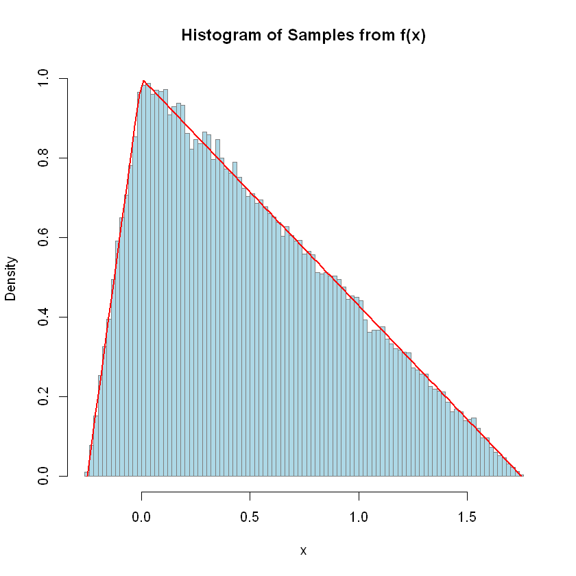

```r
# Part 4 Ques C
# Generate 99,999 random numbers
samples <- samplingHelper(99999)

# Theoretical PDF
f_x <- function(x) {
  ifelse(x < -0.25, 0,
    ifelse(x < 0, 4*x + 1,
      ifelse(x < 1.75, 1 - (4/7)*x, 0)))
}

# Plot histogram with theoretical curve
hist(samples,
     breaks = 100,
     freq = FALSE,
     col = "lightblue",
     border = "gray50",
     main = "Histogram of Samples from f(x)",
     xlab = "x")

curve(f_x(x),
      from = -0.25,
      to = 1.75,
      add = TRUE,
      lwd = 2,
      col = "red")
```

### **Part 4 Ques D**

### **Explanation and Justification of the Sampling Method**

The method used in this task is known as Inverse Transform Sampling, a standard technique for generating random samples from a known probability distribution when its cumulative distribution function (CDF) can be derived and inverted analytically.

First, the CDF $F(x)$ is obtained from the given probability density function $f(x)$. Next, the inverse function $Q(p)=F^{-1}(p)$, known as the quantile function, is derived. This function maps probabilities in $[0,1]$ to the corresponding $x$-values of the target distribution. To generate samples, we draw random values $p$ from the uniform distribution $U(0,1)$ and then transform them using $x=Q(p)$. The resulting $x$-values are distributed according to $f(x)$.

This technique works because the uniform variable $p$ represents cumulative probabilities, and the inverse CDF converts those probabilities into values consistent with the desired distribution. In this piecewise case, the split at $p=\frac{1}{8}$ ensures that each segment of $f(x)$ is correctly weighted according to its probability mass.

Finally, the histogram of the simulated samples closely matches the theoretical curve of $f(x)$, demonstrating that the inverse transform method accurately reproduces the expected distribution. Overall, this approach is both mathematically sound and computationally efficient, making it well suited for sampling from complex, piecewisedefined probability models.

### Part 4 Ques E

$$ f(x)=e^{-\pi x^2}, x \in(-\infty,+\infty) $$

The given pdf integrates to 1 and represents a rescaled normal distribution.

Cumulative Distribution Function (CDF) To find $F(x)$ :

$$ F(x)=\int_{-\infty}^x e^{-\pi t^2} d t $$

Let $u=t \sqrt{\pi} \Rightarrow d t=\frac{d u}{\sqrt{\pi}}$.

$$ F(x)=\frac{1}{\sqrt{\pi}} \int_{-\infty}^{x \sqrt{\pi}} e^{-u^2} d u $$

The error function is defined as:

$$ \operatorname{erf}(z)=\frac{2}{\sqrt{\pi}} \int_0^z e^{-t^2} d t $$

Rewriting the CDF in terms of erf:

$$ F(x)=\frac{1}{2}[1+\operatorname{erf}(\sqrt{\pi} x)] $$

Quantile Function Set $F(x)=p$ and solve for $x$ :

$$ \begin{gathered} \frac{1}{2}[1+\operatorname{erf}(\sqrt{\pi} x)]=p \\ \operatorname{erf}(\sqrt{\pi} x)=2 p-1 \end{gathered} $$

Taking the inverse error function:

$$ \begin{gathered} \sqrt{\pi} x=\operatorname{erf}^{-1}(2 p-1) \\ Q(p)=\frac{1}{\sqrt{\pi}} \operatorname{erf}^{-1}(2 p-1) \quad \text { for } 0<p<1 \end{gathered} $$

Final Answer CDF:

$$ F(x)=\frac{1}{2}[1+\operatorname{erf}(\sqrt{\pi} x)] $$

Quantile:

$$ Q(p)=\frac{1}{\sqrt{\pi}} \operatorname{erf}^{-1}(2 p-1) $$

```r
# Part 4 Ques F
# newSamplingHelper: generate n samples from f(x) = exp(-pi * x^2)
# Uses inverse transform sampling with
# Q(p) = qnorm(p) / sqrt(2 * pi)
# because F(x) = Phi(sqrt(2*pi) * x),
# where Phi is the CDF of the standard normal.

newSamplingHelper <- function(n) {
  # error handling
  if (length(n) != 1L || !is.numeric(n) || is.na(n) || n <= 0 || n != as.integer(n)) {
    stop("Input 'n' must be a positive integer.")
  }

  # Step 1: generate uniform random numbers
  p <- runif(n)

  # Step 2: apply quantile function (inverse CDF)
  numbers <- qnorm(p) / (sqrt(2 )*sqrt(pi))

  # Step 3: return results
  return(numbers)
}
```

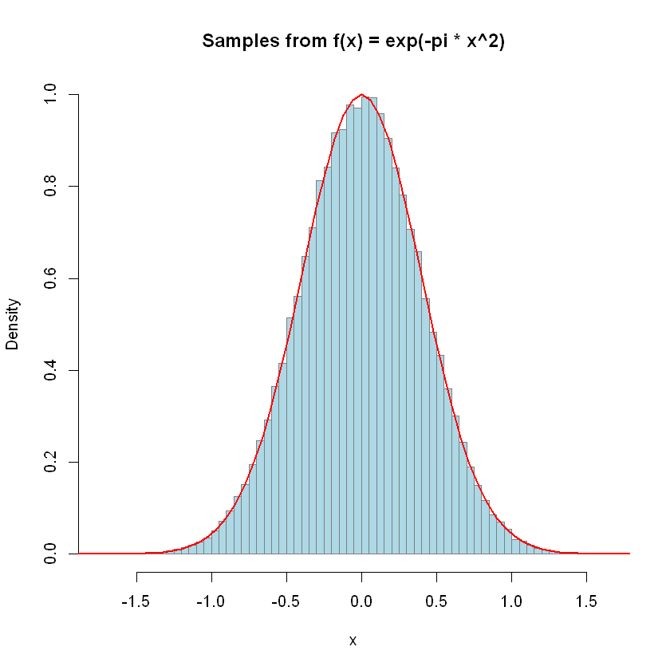

```r
# Part 4 Ques G
samples <- newSamplingHelper(99999)

f_x <- function(x) exp(-pi * x^2)

# Plot histogram and overlay curve
hist(samples,
     breaks = 100,
     freq = FALSE,
     col = "lightblue",
     border = "gray50",
     main = "Samples from f(x) = exp(-pi * x^2)",
     xlab = "x")

curve(f_x(x),
      from = -3, to = 3,
      add = TRUE,
      lwd = 2,
      col = "red")
```

### **Explanation**

The histogram of the random samples from $f(x)=e^{-\pi x^2}$ almost perfectly matches the red theoretical curve. This shows that the sampling function correctly generated data following the intended distribution. The shape is symmetric and bell-shaped like a normal (Gaussian) curve centred at 0 , meaning $f(x)$ behaves like a standard normal distribution scaled by $1 / \sqrt{2 \pi}$. Any small differences near the tails are due to random variation, confirming that the simulation and theoretical model agree very well.